##### **Significance Testing:**

This isn’t a stats course, but significance testing is a really handy technique for analysing data - the first step in learning statistical techniques in a data analyst’s/scientist’s toolkit, and can be relatively easily executed in R.

In practical terms, significance testing is quantifying how confident we are two groups are different to one another.

Suppose we wanted to test whether primary schools had significantly different total workforces to the school population overall.

```r
t.test(swfc_16 %>% filter(School_Phase == "Primary"
                          ) %>% select(Tot_Workforce_HC),
       mu = mean(swfc_16$Tot_Workforce_HC,na.rm=TRUE),
       alternative = "less")
t.test(swfc_16[swfc_16$School_Phase == "Primary",17],
       mu = mean(swfc_16$Tot_Workforce_HC,na.rm=TRUE),
       alternative = "less")
```

Let’s break the input down:

- t.test(): The technique to test for a significant difference is called a T-test - in this instance we’re carrying out a ‘one-tail’ T-test, which in this instance means checking whether the average of a sample significantly differs from the average of the entire population.
- **Argument 1:** The first argument is the sample that we want to the population against. In this instance it’s primary schools.
- **Argument 2:** mu is the average of the population.
- **Argument 3:** We want to test whether the sample average is ‘less’ than population average. This could also be ‘greater’.

```
##
##  One Sample t-test
##
## data:  swfc_16 %>% filter(School_Phase == "Primary") %>% select(Tot_Workforce_HC)
## t = -67.484, df = 16683, p-value < 2.2e-16
## alternative hypothesis: true mean is less than 59.69092
## 95 percent confidence interval:
##      -Inf 46.84931
## sample estimates:
## mean of x
##  46.52847
```

Now let’s break the output down (in reverse order from how it’s displayed):

**Simple?!?**

**Activity A8.4:** Test whether schools in Camden LA District have a significantly higher percentage of vacant posts (column name is FT_Vacant_Posts) than England as a whole, using a t-test.

Repeat for lower.

As well as comparing a sample to a population we can compare two samples. What we are doing is testing whether the difference of the averages of two samples is **significantly different** to zero, i.e. there is a difference.

In this example we’re going to test whether primary schools have a significantly different percentage of teachers who are male to schools that have a phase of ‘All Through’.

```r
t.test(Perc_Male_Teachers ~ School_Phase,
       data = (swfc_16 %>% filter(School_Phase == "Primary" |
                                    School_Phase == "All Through") %>%
                 select(School_Phase,
                        Perc_Male_Teachers)))
```

Let’s break the input down:

- t-test: As above
- **Argument 1:** This contains the variable that we’re going to compare the groups on (percentage of teachers that are male), and the characteristic that defines the groups (phase). But there’s more than one phase of school I hear you say…
- **Argument 2:** Fear not. In the second argument we use some dplyr to do some filtering. We only select schools that are primary or all through, and we only select the school phase and percentage of teachers that are male columns.

```
##
##  Welch Two Sample t-test
##
## data:  Perc_Male_Teachers by School_Phase
## t = 22.812, df = 151.8, p-value < 2.2e-16
## alternative hypothesis: true difference in means is not equal to 0
## 95 percent confidence interval:
##  15.56238 18.51366
## sample estimates:
## mean in group All Through     mean in group Primary
##                  31.81972                  14.78170
```

Now let’s break the output down:

- **Welch:** Dunno who Welch is, but their t-test is the standard one for testing two samples
- **Group means (at the bottom):** These are the means of the two samples that we’re comparing
- **Confidence intervals:** 95% of the time (i.e. 19 out of 20 times), the average of any random samples taken from each of the groups (primary and all through) will have a difference in their averages of between 15.56238 and 18.51366. Both of those numbers are above 0, so this is looking good…
- **p-value:** Again, to be confident that there is a significant difference, this number needs to be less than 0.05 (i.e. only 1 time out of 20 will random samples from primary schools and all through schools be outside the confidence intervals above)

**Activity A8.5:** Test whether schools in Camden and Northumberland LA Districts have significantly different percentage of vacant posts (column name is FT_Vacant_Posts) than England as a whole, using a two sample t-test.

**Tip:**

For more info on t-tests, go to [this page](http://www.dummies.com/education/math/statistics/how-to-test-for-an-average-difference-using-the-paired-t-test/) on dummies.com.

Also, try out [this page](https://www.graphpad.com/quickcalcs/ttest1.cfm) for an interactive two sample t-test calculator if you want a bit more practice.

#### **Iteration** (back to contents)

One of the most powerful uses of any programming language is its ability to do a task over and over again really quickly - this is known as iteration.

**Tip:** Iteration isn’t actually the most efficient way of writing code, because it processes each item it iterates over one at a time. A more efficient way to process code is to ‘vectorise’ your code - this means writing code to process all the items at once. We’ve already done this when we’ve been manipulating columns of data in one go - we could have written an iterative function to go over each item in the column and manipulate it.

That said, iteration is a really important process to learn, because it helps you understand the sort of ‘decisions’ a computer will make in the background when executing code.

There are three types of iterative function that we’ll look at:

- An if statement - a function that will do one thing if a condition is met or is true, and another thing is that condition is not met or is false
- A for loop - a function that will repeat a task for every item in a list or a certain number of iterations
- A while - function that will repeat a task for as long as a condition is met or is true

All of the functions here take a similar format:

```r
function(condition to be met){
  action to be carried out if condition is met #Note how it has to be indented
}
```

##### **if statements**

As mentioned above, if statements are for carrying out an action if a condition is met or is true.

For example, say we were trying to create a recreate whether a fictitious teacher was male or female, if we knew the probability that a teacher was male, we could build an if statement that said:

1. Generate a random number between 0 and 1
2. If that number is less than or equal to the probability that a teacher is male, then say our fictitious teacher is male
3. If that number is more than the probability that a teacher is male, then say our fictitious teacher is female

First, let’s work out the probability that a teacher is male. This is the average percentage of male teachers divided by 100, to make it a probability.

```r
prob_male <- swfc_16$Perc_Male_Teachers %>% mean(na.rm = TRUE)/100
```

Now, let’s generate our random number using the runif function.

```r
rand_num <- runif(1)
```

Now let’s write our if statement.

```r
if(rand_num<=prob_male){
  print("M")
}
```

So now if our random number is less than or equal to the probability a teacher is male that it will print ‘M’. However, if it’s over the probability, nothing will happen.

To ensure something does happen we can use the else function, which will execute an action if the condition is not met.

```r
if(rand_num<=prob_male){
  print("M")
}else{
  print("F")
}
```

**Activity A9.1:** How could we streamline the code we’ve just written by replacing object names?

##### **for loops**

A for loop - a function that will repeat a task for every item in a list or a certain number of iterations. Say we wanted to create a fictitious school which contained 10 teachers, we could write a for loop that for 10 iterations repeated the if statement above.

```r
for(i in 1:10){
  if(runif(1)<=prob_male){
    print("M")
  }else{
    print("F")

  }
}
```

Let’s break this down the for loop argument:

1. The i is the name of an object that will take a different value at each iteration (1st iteration, 2nd iteration, etc) of the for loop
2. in 1:10 details the different values i will take: 1st iteration - i=1, 2nd iteration i=2, etc.
3. The action to execute at each stage between the curly braces, which in this instance is the if statement from above

**Activity A9.2:** Adapt the for loop above to create an empty object and at each iteration add the result from the if statement to that object. The functions you’ll need are below:

```r
#For creating an empty object
character(0)

#For joining values to an existing object
c(object,value)
```

##### **while loops**

A while loop while perform an action for as long as the condition specified in the function’s argument is true.

**Activity A9.3:** Write the function below out and run it. As 2 while always be greater than 1 what is going to happen?

```r
while(1<2){
  print("This is going to take a while...")
}
```

**Tip:** Stop a bit of code from running by clicking on the red stop sign in the top right hand corner of the console.

Typically, a while loop will look like this:

```r
object <- starting_value
while(condition_of_object){
  action
  object <- change_value_of_object
}

#For example
i <- 1
while(i<5){
  print(paste0("This is a while loop, we're at iteration ", as.character(i)))
  i<-i+1
}
```

**Tip:** paste0() is a really useful function that glues strings together. It’s different to c() in that it turns multiple strings into one string, whereas c() turns them into a vector of multiple strings.

**Activity A9.4:** Add 3 while loops after your for loop above so that while i equals 1 you add ‘Headteacher’ to an object, while i is less than 5 you add ‘Senior Leader’ to the same object, and while i is greater or equal to 5 you add ‘Classroom Teacher’ to the same object.

Once this has run put the gender object and the object denoting the seniority of the teacher into a dataframe called my_school with the column headings as gender and grade.

##### **How could we use loops?**

Loops are really useful for building models of systems, to use probabilities (as we did with the gender probabilities) to predict how entities (called agents in modelling) will behave in a system. These models can be run multiple times and the outputs recorded each time to give a distribution of how likely each outcome is to occur based on different behaviours along the modelled actions.

#### **Functions** (back to contents)

We’ve used a lot of functions up until now, and understand the format of a function, with the function name and then the arguments inside the brackets. It essentially takes the form:

```r
verb(noun,adverbs)
```

Where the verb is the thing we want to do, the noun (as the first argument) is the object we want to do it to, and the adverbs (as the subsequent arguments) are the descriptions of how we want to do it.

However, there’s going to come a time when we want to do the same thing again and again, to a lot of different objectives, and there won’t be a specific function to write it. Don’t worry though, you can do write your own functions.

##### **Writing functions**

A function is comprised of three parts:

```r
function_name <- function(function_argument1,function_argument2,etc){
  function_actions
}
```

So, a function that divides an object by 100 looks like this:

```r
my_func <- function(x){
  x/100
}
```

Here x is the noun that we’re doing something to. To create the function, simply run that code.

**Activity A10.2:** Remember the code from the iteration section on deciding whether a fictional teacher was male or female?

```r
if(rand_num<=prob_male){
  print("M")
}else{
  print("F")
}
```

Turn that into a function, with the random number as the ‘noun’.

Once you’ve written it, run it with a few different numbers in the argument.

It’s also really handy for producing graphs when we want to filter them by different categories. Say we wanted to look at a histogram of the total school workforce, to get an idea of the distribution of school sizes in a particular region, we could make a graph like this (with Inner London as an example):

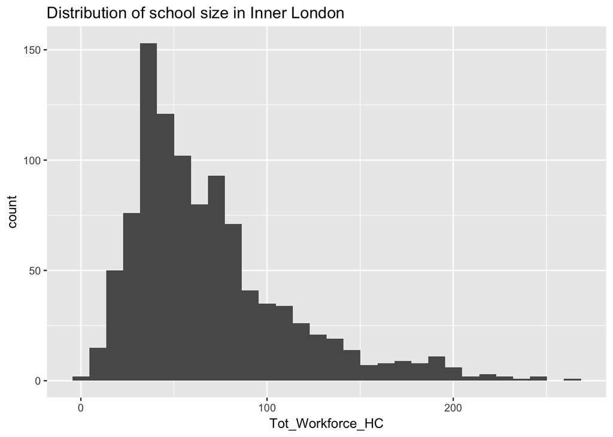

```r
ggplot(swfc_16 %>% filter(Government_Office_Region_Name == 'Inner London'),
     aes(Tot_Workforce_HC)) +
geom_histogram() +
  ggtitle('Distribution of school size in Inner London')
```

However, ‘Inner London’ could be any one of the 9 other regions in England - we could vary this value. By varying it we are making it a parameter - a value in our input code that can change.

We can produce exactly the same output by replacing the string ‘Inner London’ with an object name, and creating that object before we create the graph (remember the paste0 function that we used in the iteration section).

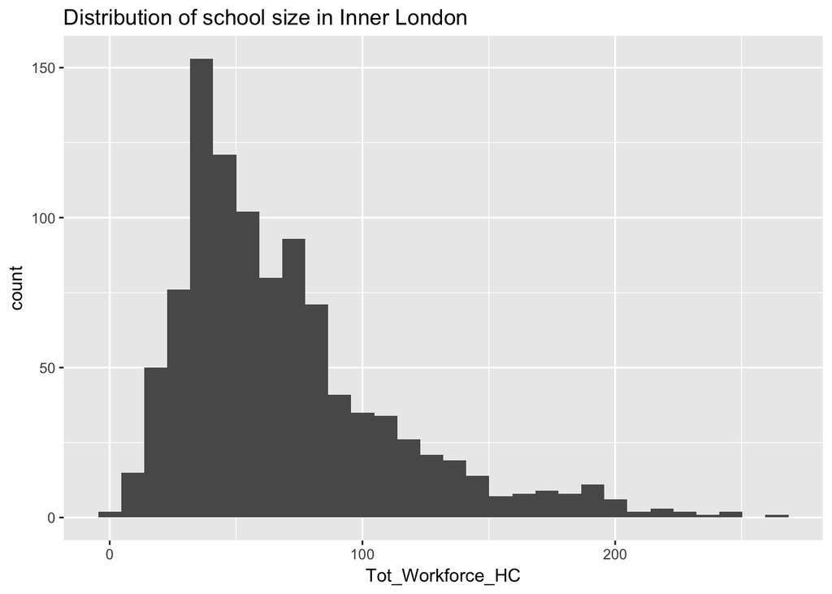

```r
region_name <- 'Inner London'

ggplot(swfc_16 %>% filter(Government_Office_Region_Name == region_name),
     aes(Tot_Workforce_HC)) +
geom_histogram() +
  ggtitle(paste0('Distribution of school size in ',region_name))
```

**Activity A10.3:** Using the code above, create a function which you could put in any region name, and as long as that region is correct, the function produces a graph.

##### **Applying functions repetitively**

Writing a lot of code get boring and laborious. Writing a lot of code that does the same thing again and again gets really boring and laborious. It can also lead to errors - if you copy and paste code enough times eventually you’ll make a mistake, which could lead to incorrect analysis.

However, as already mentioned, if you’re doing something again and again, then building a function is really useful. Suppose we do want to create graphs of all 10 regions, using the code above? We have the function to produce a graph, what we need now is to work out how to repeat the graph again and again, changing the region parameter.

We could use a for loop, but remember that’s not the most effective way. We want to ‘vectorise our code’.

A function called lapply applies a function to a list of objects.

**Activity A10.3:** The Government_Office_Region_Name column is a factor column - use levels() to generate a list of the different possible entries to that column

The lapply function works in the following way:

```r
lapply(multiple_objects_to_apply_function_to,function(argument_name) specific_function_to_apply(argument_name))
```

The word function at the start of the second argument specifies that you’re about to write a function name, and essentially says ‘make each object in the list in the first argument the value of argument_name and apply the specific function to it’.

You can choose any string you like for argument_name, as long as it’s the same in both places.

**Activity A10.3:** Use lapply to print a graph showing the distribution of school sizes in the Plot pane for every single region in England.

We can also use lapply to do the same thing to data in multiple columns. The difference here is that we want to turn the outputs of the lapply into an object. That object just so happens to be the same thing that goes in to the first argument in lapply. So if we wanted to turn all the columns with ‘Perc’ in the column title, that is those columns that are a percentage, from a number out of 100 to a number out of 1, by dividing by 100, we’d apply the following code:

```r
swfc_16[,grep("Perc", colnames(swfc_16))] <- lapply(swfc_16[,grep("Perc", colnames(swfc_16))],function(x) my_func(x))
```

Let’s break this down:

- swfc_16[,grep(“Perc”, colnames(swfc_16))] are all the columns in swfc_16 which contain ‘Perc’. The function grep finds all the columns which contain the substring ‘Perc’.
- Within lapply, the first argument is the same set of columns - we’re essentially doing an update on those columns
- The function we’re applying is my_func, which divided the object by 100

**Activity A10.3:** Use lapply to turn columns 6 to 10 (swfc_16[,grep(“Perc”, c(6:10))]) into character columns, from factor columns.

#### **Maps** (back to contents)

Maps in R are best plotted using ggplot - which is good, because we already know how to use that! However, the new thing about maps is the sort of data we’ll be using - as well as having data about certain variables, this data has a location attached to it too.

##### **Geospatial data**

Geospatial data comes in three forms:

- Polygons (shapes) - Two dimensions
- Lines - one dimension
- Points - no dimensions

Polygons and points are the most common (geospatial line data only really features when relating to travel infrastructure or people movements), so we’ll focus on these two.

However, before we get to plotting points or polygons we need to go through some geospatial data basics.

```r
cities <- "../1_data/SHPs/england_cities.shp" %>% readOGR()

england <- "../1_data/SHPs/England_LA_2016.shp" %>%
  readOGR()

plot(england) +
  plot(cities,add=T,col="red")

cities <- spTransform(cities, CRS("+init=epsg:27700"))

england <- "../1_data/SHPs/England_LA_2016.shp" %>%
  readOGR() %>%
  fortify(region="LA15NM") %>%
  as.tbl() %>%
  dplyr::select(Easting = long,
                Northing = lat,
                LAD16NM = id,
                group)

cities <- "../1_data/SHPs/england_cities.shp" %>%
  readOGR() %>%
  spTransform(CRS("+init=epsg:27700")) %>%
  data.frame() %>%
  select(City,
         Easting = coords.x1,
         Northing = coords.x2)

ggplot()+
  geom_polygon(data=england,
               aes(Easting,Northing,group=group),
               col="grey",
               fill=NA) +
  geom_point(data=cities,
             aes(Easting,Northing),
             col="red") +
  coord_equal() +
  theme_minimal() +
  geom_text(data=cities,
            aes(Easting,Northing,label=cities$City),
            check_overlap = TRUE,
            col="blue",
            hjust = 1.1,
            vjust=0.3)
```

##### **Point maps**

```r
Wiltshire <- "../1_Data/SHPs/England_LA_2016.shp" %>%
  readOGR() %>%
  subset(LA15NM == "Wiltshire") %>%
  fortify(region="LA15NM") %>%
  as.tbl() %>%
  dplyr::select(Easting = long,
                Northing = lat,
                LA15NM = id,
                group)

ggplot() +
  geom_polygon(data=Wiltshire,aes(Easting,Northing),col="grey",fill=NA) +
  coord_equal() +
  theme_minimal() +
  theme(axis.line=element_blank(),
        axis.text.x=element_blank(),
        axis.text.y=element_blank(),
        axis.ticks=element_blank(),
        axis.title.x=element_blank(),
        axis.title.y=element_blank(),
        panel.background=element_blank(),
        panel.border=element_blank(),
        panel.grid.major=element_blank(),
        panel.grid.minor=element_blank(),
        plot.background=element_blank(),
        legend.title=element_blank())

wiltshire_schools <- "../1_Data/wiltshire_schools.csv" %>% read_csv()

wiltshire_schools %>% write_csv("wiltshire_schools.csv")

ggplot() +
  geom_point(data=wiltshire_schools,aes(Easting,Northing,size=Tot_Workforce_HC,
                                        col=School_Phase)) +
  geom_polygon(data=Wiltshire,aes(Easting,Northing),col="grey",fill=NA) +
  coord_equal() +
  theme_minimal() +
  theme(axis.line=element_blank(),
        axis.text.x=element_blank(),
        axis.text.y=element_blank(),
        axis.ticks=element_blank(),
        axis.title.x=element_blank(),
        axis.title.y=element_blank(),
        panel.background=element_blank(),
        panel.border=element_blank(),
        panel.grid.major=element_blank(),
        panel.grid.minor=element_blank(),
        plot.background=element_blank(),
        legend.title=element_blank())
```

##### **Chloropleth maps**

```r
library(rgdal)

England <- readOGR("../1_data/SHPs/England_Regions.shp")
plot(England)

region_ave_salary <- "../1_data/region_ave_salary.csv" %>%
  read_csv()

Reg_England_df <- England %>%
  fortify(region="rgn16nm") %>%
  as.tbl() %>%
  dplyr::select(Easting = long,
                Northing = lat,
                Region = id,
                group) %>%
  left_join(region_ave_salary,c("Region"="Government_Office_Region_Name"))

ggplot() +
  geom_polygon(data=Reg_England_df,aes(Easting,Northing,
                                       group=group,
                                       fill=ave_sal),
               col="white") +
  coord_equal() +
  theme_minimal() +
  theme(axis.line=element_blank(),
        axis.text.x=element_blank(),
        axis.text.y=element_blank(),
        axis.ticks=element_blank(),
        axis.title.x=element_blank(),
        axis.title.y=element_blank(),
        panel.background=element_blank(),
        panel.border=element_blank(),
        panel.grid.major=element_blank(),
        panel.grid.minor=element_blank(),
        plot.background=element_blank(),
        legend.title=element_blank())
```

#### **R Markdown** (back to contents)

We now know how to do a range of data analysis, as well as producing a lot of different visualisations. Now we need to know how to compile all of that into a report, and automatically produce that report. The has numerous benefits over the traditional Excel and Word approach to writing out analysis:

- Faster, once the template is written
- More robust - errors are less likely to occur, particuarly when copying from Excel to Word
- Can be updated immediately if/when data changes

There are two elements to R Markdown, the text (which has a number of ways of formatting it) and the code (which can be displayed and included in different ways). We’ll look at both of these, but first, we need to open an R Markdown file:

1. Go to File
2. Go to New File
3. Click on R Markdown
4. A new tab will open up in the script pane - have a look at it as it contains an example R Markdown template
5. in the top right hand corner of the script pane click on the arrow next to Knit and click on ‘Knit to HTML’
6. Save the R Markdown file in the ‘2_code’ folder
7. The code will run and the output will pop up upon completion
8. Compare this to the input file
9. The output file will have saved in the ‘2_code’ folder - it shouldn’t output to here, but we’ll sort that later

This is how you generate an R Markdown document. When you make changes to it from now on, you won’t have to specify the name and save location every time you knit it.

**Tip:** HTML is the preferable output - it is more versatile in designs and can include interactive elements, however if you want to you can also output to Word, and if you have additional software installed (called LaTex and pronounced ‘lay-tec’) you can output straight to PDF.

##### **Text**

We can see from the template above that there are a range of ways of formatting text to render it to look good in a report.

First of all, headings. Headings are generated by sequential hashes - one hash is the largest heading, and six hashes is the smallest heading. These can be used to create a series of sub-headings in documents.

# Heading 1